# Support Vector Machine

서포트 벡터 머신은 지도학습(Supervised learning)에서 유용하게 쓰이는 알고리즘이다.  
실습시간을 통해 직접 알고리즘을 구현해 보고 직관을 기르도록 하자.

```python
# 실습에 필요한 패키지 불러오기
import numpy as np
import sklearn
import matplotlib.pyplot as plt
import util
```

# [예제] Iris 데이터를 통한 실습

scikit-learn에서 Iris 데이터를 가져오자.  
Iris 데이터는 통계학자인 피셔가 소개한 데이터로, 붓꽃의 3가지 종에 대해 꽃받침sepal과 꽃잎petal의 길이를 정리한 데이터다

```python
# sklearn 라이브러리에서 datasets를 불러온다.
from sklearn import datasets
# iris데이터는 load_iris()함수를 사용해 불러올 수 있다.
iris = datasets.load_iris()
```

```python
#iris 내부를 들여다보자
iris
```

```
{'data': array([[5.1, 3.5, 1.4, 0.2],
        [4.9, 3. , 1.4, 0.2],
        [4.7, 3.2, 1.3, 0.2],
        [4.6, 3.1, 1.5, 0.2],
        [5. , 3.6, 1.4, 0.2],
        [5.4, 3.9, 1.7, 0.4],
        [4.6, 3.4, 1.4, 0.3],
        [5. , 3.4, 1.5, 0.2],
        [4.4, 2.9, 1.4, 0.2],
        [4.9, 3.1, 1.5, 0.1],
        [5.4, 3.7, 1.5, 0.2],
        [4.8, 3.4, 1.6, 0.2],
        [4.8, 3. , 1.4, 0.1],
        [4.3, 3. , 1.1, 0.1],
        [5.8, 4. , 1.2, 0.2],
        [5.7, 4.4, 1.5, 0.4],
        [5.4, 3.9, 1.3, 0.4],
        [5.1, 3.5, 1.4, 0.3],
        [5.7, 3.8, 1.7, 0.3],
        [5.1, 3.8, 1.5, 0.3],
        [5.4, 3.4, 1.7, 0.2],
        [5.1, 3.7, 1.5, 0.4],
        [4.6, 3.6, 1. , 0.2],
        [5.1, 3.3, 1.7, 0.5],
        [4.8, 3.4, 1.9, 0.2],
        [5. , 3. , 1.6, 0.2],
        [5. , 3.4, 1.6, 0.4],
        [5.2, 3.5, 1.5, 0.2],
        [5.2, 3.4, 1.4, 0.2],
        [4.7, 3.2, 1.6, 0.2],
        [4.8, 3.1, 1.6, 0.2],
        [5.4, 3.4, 1.5, 0.4],
        [5.2, 4.1, 1.5, 0.1],
        [5.5, 4.2, 1.4, 0.2],
        [4.9, 3.1, 1.5, 0.1],
        [5. , 3.2, 1.2, 0.2],
        [5.5, 3.5, 1.3, 0.2],
        [4.9, 3.1, 1.5, 0.1],
        [4.4, 3. , 1.3, 0.2],
        [5.1, 3.4, 1.5, 0.2],
```

[output cut: 108 more lines]

```
        [6.2, 3.4, 5.4, 2.3],
        [5.9, 3. , 5.1, 1.8]]),
 'target': array([0, 0, 0, 0, 0, 0, 0, 0, 0, 0, 0, 0, 0, 0, 0, 0, 0, 0, 0, 0, 0, 0,
        0, 0, 0, 0, 0, 0, 0, 0, 0, 0, 0, 0, 0, 0, 0, 0, 0, 0, 0, 0, 0, 0,
        0, 0, 0, 0, 0, 0, 1, 1, 1, 1, 1, 1, 1, 1, 1, 1, 1, 1, 1, 1, 1, 1,
        1, 1, 1, 1, 1, 1, 1, 1, 1, 1, 1, 1, 1, 1, 1, 1, 1, 1, 1, 1, 1, 1,
        1, 1, 1, 1, 1, 1, 1, 1, 1, 1, 1, 1, 2, 2, 2, 2, 2, 2, 2, 2, 2, 2,
        2, 2, 2, 2, 2, 2, 2, 2, 2, 2, 2, 2, 2, 2, 2, 2, 2, 2, 2, 2, 2, 2,
        2, 2, 2, 2, 2, 2, 2, 2, 2, 2, 2, 2, 2, 2, 2, 2, 2, 2]),
 'target_names': array(['setosa', 'versicolor', 'virginica'], dtype='<U10'),
 'DESCR': 'Iris Plants Database\n====================\n\nNotes\n-----\nData Set Characteristics:\n    :Number of Instances: 150 (50 in each of three classes)\n    :Number of Attributes: 4 numeric, predictive attributes and the class\n    :Attribute Information:\n        - sepal length in cm\n       …
 'feature_names': ['sepal length (cm)',
  'sepal width (cm)',
  'petal length (cm)',
  'petal width (cm)']}
```

```python
# 첫번째(sepal length)와 세번째(petal length) 변수만 추출하여 x로 할당하고, 타겟 변수만 추출하여 y로 할당하자.
x = iris.data[:, [0, 2]]
y = iris.target
```

```python
# y의 라벨값을 확인해보자.
print('Class labels:', np.unique(y))
```

```
Class labels: [0 1 2]
```

## 학습세트와 테스트 세트 나누기

데이터의 70%를 training에 사용하고 나머지 30%를 test에 사용하기 위해 **split**한다.

```python
# sklearn 라이브러리에서 제공하는 train_test_split 함수를 불러오자
from sklearn.model_selection import train_test_split
```

```python
# test_size의 비율을 30%로, 시드넘버는 1로, 층화추출하여 데이터를 나누자.
x_train, x_test, y_train, y_test = train_test_split(x, y, test_size=0.3, random_state=1, stratify=y)
```

```python
# 데이터가 비율에 맞게 잘 나누어졌는지 확인해보자.
print('Labels counts in y:', len(y))
print('Labels counts in y_train:', len(y_train))
print('Labels counts in y_test:', len(y_test))
```

```
Labels counts in y: 150
Labels counts in y_train: 105
Labels counts in y_test: 45
```

## 독립변수 Scaling 하기

X_train의 통계값을 이용하여 **정규화**시킴. PCA 등을 할 때 필요하다.  
실습수업에서는 과정을 이해하기 위해 진행해보도록 하자.

```python
# sklearn 라이브러리에서 제공하는 StandardScaler라는 정규화 함수를 사용하자.
from sklearn.preprocessing import StandardScaler
```

```python
# StandardScaler 함수의 인스턴스인 sc라는 객체를 만들어 x_train 데이터를 넣어보자.
sc = StandardScaler()
sc.fit(x_train)
# X_train이 피팅되어 평균과 분산을 구할수 있다.
print('mean of X_train:',sc.mean_)
print('var of X_train:',sc.var_)
```

```
mean of X_train: [5.85714286 3.78952381]
var of X_train: [0.6894966  3.21484263]
```

```python
# 이번에는 x_train과 x_test데이터를 평균 0, 표준편차 1로 정규화 시켜보도록 하자.
x_train_std = sc.transform(x_train)
x_test_std = sc.transform(x_test)
```

```python
# 출력해서 X_train_std를 확인해보자.
print(x_train_std)
```

```
[[-0.4301064  -1.33269725]
 [-0.55053619 -1.16537974]
 [ 0.65376173  0.84243039]
 [ 1.0150511   1.0655204 ]
 [-1.03225536 -1.44424226]
 [ 1.0150511   1.0097479 ]
 [ 2.09891923  1.56747294]
 [-0.06881702 -1.44424226]
 [ 1.61720006  1.12129291]
 [ 0.89462131  0.45202286]
 [-1.03225536 -0.27301968]
 [-0.79139578  0.06161534]
 [-1.39354474 -1.38846976]
 [ 0.29247235  0.50779537]
 [-0.4301064   0.11738784]
 [-0.06881702  0.73088538]
 [-1.27311494 -1.05383474]
 [-1.03225536 -0.16147468]
 [-0.06881702  0.06161534]
 [-1.39354474 -1.22115225]
 [ 0.41290214  0.56356787]
 [ 2.21934902  1.73479045]
 [ 0.65376173  0.39625036]
 [-0.18924682  0.39625036]
 [-0.4301064   0.00584283]
 [ 0.53333194  1.0097479 ]
 [ 0.29247235  0.50779537]
 [ 0.29247235  1.0097479 ]
 [ 0.77419152  1.12129291]
 [-0.06881702  0.73088538]
 [-0.18924682  0.17316034]
 [-0.91182557 -1.27692475]
 [ 2.21934902  1.62324544]
 [ 0.53333194  0.67511288]
 [ 0.17204256  0.56356787]
 [ 0.65376173  1.0097479 ]
 [ 0.05161277  0.22893285]
 [ 2.21934902  1.62324544]
 [ 0.65376173  0.9539754 ]
 [-0.91182557 -1.22115225]
```

[output cut: 50 more lines]

```
 [ 1.1354809   1.17706541]
 [-0.30967661  0.06161534]
 [-0.18924682  0.22893285]
 [ 0.41290214  0.28470535]
 [-0.79139578 -1.27692475]
 [ 1.0150511   0.78665788]
 [ 0.53333194  0.34047786]
 [-0.4301064  -1.38846976]
 [-1.27311494 -1.33269725]
 [ 1.0150511   0.67511288]
 [-1.63440432 -1.38846976]
 [-0.06881702  0.11738784]
 [-1.03225536 -1.22115225]
 [-1.51397453 -1.27692475]
 [-1.75483411 -1.38846976]]
```

```python
# x_train_std의 평균과 표준편차를 확인해보자.
print('Mean of x_train_std :',np.mean(x_train_std[:,0]), np.mean(x_train_std[:,1]))
print('Std of x_train_std :',np.std(x_train_std[:,0]), np.std(x_train_std[:,1]))
```

```
Mean of x_train_std : 1.541623971336646e-15 1.1207965772406342e-16
Std of x_train_std : 1.0 1.0
```

## C가 작은 경우(오분류를 관대하게 허용)

```python
# SVC 클래스에 kernel='linear', 시드넘버는 1, C=0.1로 두고 모델을 피팅시키자.
from sklearn.svm import SVC
svm_smallc = SVC(kernel='linear', random_state=1, C=0.1)
svm_smallc.fit(x_train_std, y_train)
```

```
SVC(C=0.1, cache_size=200, class_weight=None, coef0=0.0,
  decision_function_shape='ovr', degree=3, gamma='auto', kernel='linear',
  max_iter=-1, probability=False, random_state=1, shrinking=True,
  tol=0.001, verbose=False)
```

```python
# 데이터를 모두 펼쳐놓고 결정경계 그림을 그리고자 한다.
# train과 test로 나누었던 데이터를 다시 합쳐보자.
x_combined_std = np.vstack((x_train_std, x_test_std))
y_combined = np.hstack((y_train, y_test))
```

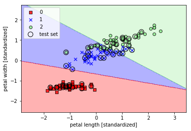

```python
# 데이터를 모두 표시하고 결정경계를 보여주는 plot_decision_regions 함수를 이용하자.
util.plot_decision_regions(x_combined_std, y_combined, classifier=svm_smallc, test_idx=range(105, 150))
plt.xlabel('petal length [standardized]')
plt.ylabel('petal width [standardized]')
plt.legend(loc='upper left')
```

```python
# svm_smallc모델에 X_test_std데이터를 넣어 y값을 예측한다.
y_pred = svm_smallc.predict(x_test_std)

# 실제 y_pred값을 확인하고, y_test값과 y_pred값이 다른 것이 있는지 확인한다.
y_pred,(y_test != y_pred)
```

```
(array([2, 0, 0, 1, 2, 1, 2, 1, 2, 0, 0, 1, 0, 1, 0, 2, 2, 1, 1, 2, 2, 0,
        2, 1, 1, 1, 1, 2, 0, 1, 0, 0, 1, 1, 2, 2, 0, 0, 0, 2, 2, 1, 2, 0,
        0]),
 array([False, False, False,  True,  True, False, False, False, False,
        False, False,  True, False, False, False,  True, False, False,
        False, False, False, False,  True,  True, False, False, False,
        False, False,  True, False, False, False, False, False, False,
        False, False, False,  True, False,  True,  True, False, False]))
```

```python
# y_test와 y_pred가 다른 값이 몇개 있는지 확인한다.
print('Misclassified samples: %d' % (y_test != y_pred).sum())
```

```
Misclassified samples: 10
```

```python
# sklearn 라이브러리에서 정확도를 구하는 accuracy_score 함수를 불러온다.
from sklearn.metrics import accuracy_score

# y_test와 y_pred을 넣고 정확도를 계산한다.
print('Accuracy: %.2f' % accuracy_score(y_test, y_pred))
```

```
Accuracy: 0.78
```

## C가 큰 경우(오분류를 엄격하게 규제)

```python
# SVC 클래스에 kernel='linear', 시드넘버는 1, C=10로 두고 모델을 피팅시키자.
svm_largec = SVC(kernel='linear', random_state=1, C=10)
svm_largec.fit(x_train_std, y_train)
```

```
SVC(C=10, cache_size=200, class_weight=None, coef0=0.0,
  decision_function_shape='ovr', degree=3, gamma='auto', kernel='linear',
  max_iter=-1, probability=False, random_state=1, shrinking=True,
  tol=0.001, verbose=False)
```

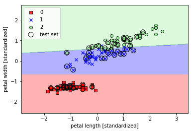

```python
# 데이터를 모두 표시하고 결정경계를 보여주는 plot_decision_regions 함수를 이용하자.
util.plot_decision_regions(x_combined_std, y_combined, classifier=svm_largec, test_idx=range(105, 150))
plt.xlabel('petal length [standardized]')
plt.ylabel('petal width [standardized]')
plt.legend(loc='upper left')
```

## 모델 평가하기 - svm_largec

```python
# svm_largec모델에 X_test_std데이터를 넣어 y값을 예측한다.
y_pred = svm_largec.predict(x_test_std)

# 실제 y_pred값을 확인하고, y_test값과 y_pred값이 다른 것이 있는지 확인한다.
y_pred,(y_test != y_pred)
```

```
(array([2, 0, 0, 1, 1, 1, 2, 1, 2, 0, 0, 2, 0, 1, 0, 1, 2, 1, 1, 2, 2, 0,
        1, 2, 1, 1, 1, 2, 0, 2, 0, 0, 1, 1, 2, 2, 0, 0, 0, 1, 2, 2, 1, 0,
        0]),
 array([False, False, False,  True, False, False, False, False, False,
        False, False, False, False, False, False, False, False, False,
        False, False, False, False, False, False, False, False, False,
        False, False, False, False, False, False, False, False, False,
        False, False, False, False, False, False, False, False, False]))
```

```python
# y_test와 y_pred가 다른 값이 몇개 있는지 확인한다.
print('Misclassified samples: %d' % (y_test != y_pred).sum())
```

```
Misclassified samples: 1
```

```python
# sklearn 라이브러리에서 정확도를 구하는 accuracy_score 함수를 불러온다.
from sklearn.metrics import accuracy_score

# y_test와 y_pred을 넣고 정확도를 계산한다.
print('Accuracy: %.2f' % accuracy_score(y_test, y_pred))
```

```
Accuracy: 0.98
```

## Kernel SVM : gamma의 값에 따른 결정경계면의 변화

## gamma가 작을때 : 1

```python
# SVC 클래스에 kernel='rbf', 시드넘버는 1, gamma=1로 두고 모델을 피팅시키자.
svm_k_smallg = SVC(kernel='rbf', random_state=1, gamma=1)
svm_k_smallg.fit(x_train_std, y_train)
```

```
SVC(C=1.0, cache_size=200, class_weight=None, coef0=0.0,
  decision_function_shape='ovr', degree=3, gamma=1, kernel='rbf',
  max_iter=-1, probability=False, random_state=1, shrinking=True,
  tol=0.001, verbose=False)
```

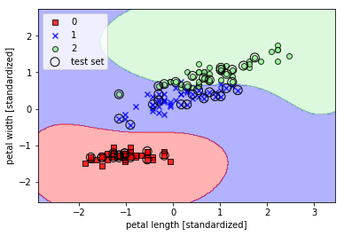

```python
# 데이터를 모두 표시하고 결정경계를 보여주는 plot_decision_regions 함수를 이용하자.
util.plot_decision_regions(x_combined_std, y_combined, classifier=svm_k_smallg, test_idx=range(105, 150))
plt.xlabel('petal length [standardized]')
plt.ylabel('petal width [standardized]')
plt.legend(loc='upper left')
```

## 모델 평가하기 - svm_k_smallg

```python
# svm_k_smallg모델에 X_test_std데이터를 넣어 y값을 예측한다.
y_pred = svm_k_smallg.predict(x_test_std)

# 실제 y_pred값을 확인하고, y_test값과 y_pred값이 다른 것이 있는지 확인한다.
y_pred,(y_test != y_pred)
```

```
(array([2, 0, 0, 1, 1, 1, 2, 1, 2, 0, 0, 1, 0, 1, 0, 1, 2, 1, 1, 2, 2, 0,
        1, 1, 1, 1, 1, 2, 0, 1, 0, 0, 1, 1, 2, 2, 0, 0, 0, 1, 2, 2, 1, 0,
        0]),
 array([False, False, False,  True, False, False, False, False, False,
        False, False,  True, False, False, False, False, False, False,
        False, False, False, False, False,  True, False, False, False,
        False, False,  True, False, False, False, False, False, False,
        False, False, False, False, False, False, False, False, False]))
```

```python
# y_test와 y_pred가 다른 값이 몇개 있는지 확인한다.
print('Misclassified samples: %d' % (y_test != y_pred).sum())
```

```
Misclassified samples: 4
```

```python
# sklearn 라이브러리에서 정확도를 구하는 accuracy_score 함수를 불러온다.
from sklearn.metrics import accuracy_score

# y_test와 y_pred을 넣고 정확도를 계산한다.
print('Accuracy: %.2f' % accuracy_score(y_test, y_pred))
```

```
Accuracy: 0.91
```

## gamma가 클때 : 100

```python
# SVC 클래스에 kernel='rbf', 시드넘버는 1, gamma=100로 두고 모델을 피팅시키자.
svm_k_largeg = SVC(kernel='rbf', random_state=1, gamma=100)
svm_k_largeg.fit(x_train_std, y_train)
```

```
SVC(C=1.0, cache_size=200, class_weight=None, coef0=0.0,
  decision_function_shape='ovr', degree=3, gamma=100, kernel='rbf',
  max_iter=-1, probability=False, random_state=1, shrinking=True,
  tol=0.001, verbose=False)
```

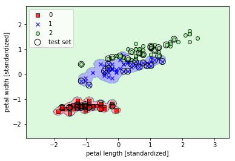

```python
# 데이터를 모두 표시하고 결정경계를 보여주는 plot_decision_regions 함수를 이용하자.
util.plot_decision_regions(x_combined_std, y_combined, classifier=svm_k_largeg, test_idx=range(105, 150))
plt.xlabel('petal length [standardized]')
plt.ylabel('petal width [standardized]')
plt.legend(loc='upper left')
```

## 모델 평가하기 - svm_k_largeg

```python
# svm_k_largeg모델에 X_test_std데이터를 넣어 y값을 예측한다.
y_pred = svm_k_largeg.predict(x_test_std)

# 실제 y_pred값을 확인하고, y_test값과 y_pred값이 다른 것이 있는지 확인한다.
y_pred,(y_test != y_pred)
```

```
(array([2, 0, 0, 2, 1, 1, 2, 1, 2, 0, 0, 2, 0, 1, 0, 1, 1, 1, 1, 2, 2, 0,
        1, 2, 1, 2, 1, 2, 0, 2, 0, 0, 1, 1, 2, 2, 0, 0, 0, 1, 2, 2, 1, 0,
        0]),
 array([False, False, False, False, False, False, False, False, False,
        False, False, False, False, False, False, False,  True, False,
        False, False, False, False, False, False, False,  True, False,
        False, False, False, False, False, False, False, False, False,
        False, False, False, False, False, False, False, False, False]))
```

```python
# y_test와 y_pred가 다른 값이 몇개 있는지 확인한다.
print('Misclassified samples: %d' % (y_test != y_pred).sum())
```

```
Misclassified samples: 2
```

```python
# sklearn 라이브러리에서 정확도를 구하는 accuracy_score 함수를 불러온다.
from sklearn.metrics import accuracy_score

# y_test와 y_pred을 넣고 정확도를 계산한다.
print('Accuracy: %.2f' % accuracy_score(y_test, y_pred))
```

```
Accuracy: 0.96
```

# [예제] 자체생성데이터

예측하고자 하는 종속변수가 범주인 "분류(Classification)" 문제를 간단한 데이터를 직접 생성하여 살펴보도록 하자.

```python
# sklearn 라이브러리에서 제공하는 samples_generator를 사용하여 2분류의 점을 생성하자
# 샘플의 개수는 50개, 집단은 2개, 시드넘버는 0, 집단의 표준편차는 0.6
from sklearn.datasets.samples_generator import make_blobs
x, y = make_blobs(n_samples=50, centers=2,
                  random_state=0, cluster_std=0.60)
```

```python
# X와 y를 살펴보자
print(x),print(y)
```

```
[[ 1.41281595  1.5303347 ]
 [ 1.81336135  1.6311307 ]
 [ 1.43289271  4.37679234]
 [ 1.87271752  4.18069237]
 [ 2.09517785  1.0791468 ]
 [ 2.73890793  0.15676817]
 [ 3.18515794  0.08900822]
 [ 2.06156753  1.96918596]
 [ 2.03835818  1.15466278]
 [-0.04749204  5.47425256]
 [ 1.71444449  5.02521524]
 [ 0.22459286  4.77028154]
 [ 1.06923853  4.53068484]
 [ 1.53278923  0.55035386]
 [ 1.4949318   3.85848832]
 [ 1.1641107   3.79132988]
 [ 0.74387399  4.12240568]
 [ 2.29667251  0.48677761]
 [ 0.44359863  3.11530945]
 [ 0.91433877  4.55014643]
 [ 1.67467427  0.68001896]
 [ 2.26908736  1.32160756]
 [ 1.5108885   0.9288309 ]
 [ 1.65179125  0.68193176]
 [ 2.49272186  0.97505341]
 [ 2.33812285  3.43116792]
 [ 0.67047877  4.04094275]
 [-0.55552381  4.69595848]
 [ 2.16172321  0.6565951 ]
 [ 2.09680487  3.7174206 ]
 [ 2.18023251  1.48364708]
 [ 0.43899014  4.53592883]
 [ 1.24258802  4.50399192]
 [ 0.00793137  4.17614316]
 [ 1.89593761  5.18540259]
 [ 1.868336    0.93136287]
 [ 2.13141478  1.13885728]
 [ 1.06269622  5.17635143]
 [ 2.33466499 -0.02408255]
 [ 0.669787    3.59540802]
 [ 1.07714851  1.17533301]
 [ 1.54632313  4.212973  ]
 [ 1.56737975 -0.1381059 ]
 [ 1.35617762  1.43815955]
 [ 1.00372519  4.19147702]
 [ 1.29297652  1.47930168]
 [ 2.94821884  2.03519717]
 [ 0.3471383   3.45177657]
 [ 2.76253526  0.78970876]
 [ 0.76752279  4.39759671]]
[1 1 0 0 1 1 1 1 1 0 0 0 0 1 0 0 0 1 0 0 1 1 1 1 1 0 0 0 1 0 1 0 0 0 0 1 1
 0 1 0 1 0 1 1 0 1 1 0 1 0]
```

```
(None, None)
```

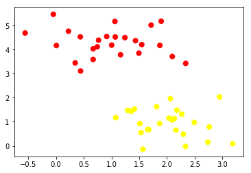

```python
# 생성한 점을 그래프 화면에 구현해보도록 하자.(c는 점의 색깔, s는 점의 크기, cmap은 colormap)
plt.scatter(x[:, 0], x[:, 1], c=y, s=50, cmap='autumn')
```

선형분리 classifier는 두 데이터 세트를 분리하는 직선을 그려서 모델을 생성함.  
위와 같은 2차원 데이터의 경우 손으로도 쉽게 분리할 수 있음.  
그러나, 어떤 직선이 두 집단을 분류하는 최적의 직선인지 결정하는것은 쉽지 않음

## Fitting a support vector machine

이제 Scikit-Learn이라는 패키지에서 지원하는 서포트 벡터 머신 분류기를 사용해보자.  
기본적으로, 선형 커널을 사용하고 매개변수 C를 매우 큰 수로 설정하도록 하자. (이것들의 의미는 아래 파트에서 살펴볼 것임)

```python
# sklearn 라이브러리의 서브 디렉토리 svm에서 SVC라는 클래스만 불러오도록 하자.
from sklearn.svm import SVC
```

```python
# SVC의 옵션을 kernel='linear', C=1E10로 지정한 객체 "model"을 생성한다.
model = SVC(kernel='linear', C=1E10)
```

```python
# 위에서 생성한 x, y 자료를 사용하여 서포트벡터 머신 모델에 피팅시킨다.(학습이 완료됨)
model.fit(x, y)
```

```
SVC(C=10000000000.0, cache_size=200, class_weight=None, coef0=0.0,
  decision_function_shape='ovr', degree=3, gamma='auto', kernel='linear',
  max_iter=-1, probability=False, random_state=None, shrinking=True,
  tol=0.001, verbose=False)
```

학습을 통해 어떤 일이 진행되었는지 잘 시각화하기 위해 SVM결정 경계를 그릴수 있는 함수를 이용하자

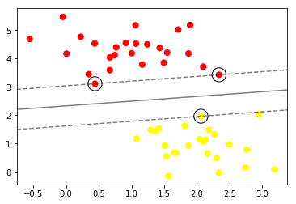

```python
# 위에서 구현했던 그래프를 다시 생성함.
# (x의 첫번째 열과 두번째 열을 사용, c는 점의 색깔, s는 점의 크기, cmap은 colormap)
plt.scatter(x[:, 0], x[:, 1], c=y, s=50, cmap='autumn')

# util모듈의 plot_decision을 사용하여 피팅한 모델의 결정경계를 그려보자.
util.plot_decision(model)
```

위는 sklearn의 SVC를 사용하여 피팅한 모델의 결정경계를 나타낸 그래프이다.  
이 결정경계는 두 데이터 세트 점 사이의 "Margin"을 최대화하는 분리선이다.  
몇몇 데이터는 점선에 맞닿아 있는데, 이 점들은 'Support Vector"라고 부른다.

```python
# 학습된 모델에 구해진 서포트 벡터들을 직접 살펴보자
model.support_vectors_
```

```
array([[0.44359863, 3.11530945],
       [2.33812285, 3.43116792],
       [2.06156753, 1.96918596]])
```

## Tuning the SVM: Softening Margins

앞서 수행한 학습들은 분류하고자 하는 두 집단이 깨끗하게 분리되어 있는 상황에서 진행되었다.  
그러나 데이터가 약간의 중복이 존재하거나 이상치가 존재한다면 어떨까?

```python
# 결정경계가 모호한 데이터 셋을 생성하여 보자.
# 샘플의 개수는 200개, 집단은 2개, 시드넘버는 0, 집단의 표준편차는 0.8
x, y = make_blobs(n_samples=200, centers=2,
                  random_state=0, cluster_std=0.8)
```

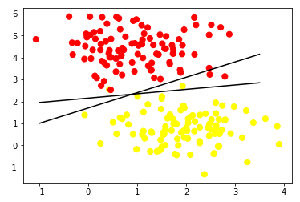

```python
# 해당 데이터셋을 scatter plot으로 표현해 보자.
# (x의 첫번째 열과 두번째 열을 사용, c는 점의 색깔, s는 점의 크기, cmap은 colormap)
plt.scatter(x[:, 0], x[:, 1], c=y, s=50, cmap='autumn')

# 기울기가 m, 절편이 b인 값을 갖는 직선을 반복문을 사용하여 그려보자.
for m, b in [(0.7, 1.7), (0.2, 2.15)]:
    xfit=np.linspace(-1, 3.5)
    yfit = m * xfit + b
    plt.plot(xfit, yfit, 'k')
```

전통적인 SVM 방식은 하드마진(Hard Margin)방법이라고 한다.  
하드마진 방식은 매우 엄격하게 두개의 클래스를 분리하는 방법으로, 모든 입력값은 반드시 한 클래스에 속해야 한다.  
하지만 몇개의 노이즈로 인해 두 그룹을 구별하는 초평면을 구하기가 어려운 경우가 존재한다.

소프트마진(Soft Margin)방법은 경계선을 두고 약간의 오류를 인정하는 방법이다.  
C값을 조정가능한 값으로 설정하여 오류를 인정하는 정도를 결정해 줄 수 있다.

```python
# 위에서 살펴본 데이터셋을 다시 생성한다.
# 샘플의 개수는 200개, 집단은 2개, 시드넘버는 0, 집단의 표준편차는 0.8
x,y=make_blobs(n_samples=200, centers=2, random_state=0, cluster_std=0.8)
```

```python
# SVC의 옵션을 kernel='linear', C=10, C=0.5로 지정한 객체 "model1"과 "model2"를 각각 생성한다.
model1 = SVC(kernel='linear', C=10)
model2 = SVC(kernel='linear', C=0.5)
```

```python
# 위에서 생성한 (x, y) 자료를 사용하여 각각 서포트벡터 머신 모델에 피팅시킨다.(학습이 완료됨)
model1.fit(x, y)
model2.fit(x, y)
```

```
SVC(C=0.5, cache_size=200, class_weight=None, coef0=0.0,
  decision_function_shape='ovr', degree=3, gamma='auto', kernel='linear',
  max_iter=-1, probability=False, random_state=None, shrinking=True,
  tol=0.001, verbose=False)
```

```
Text(0.5,1,'C = 0.5')
```

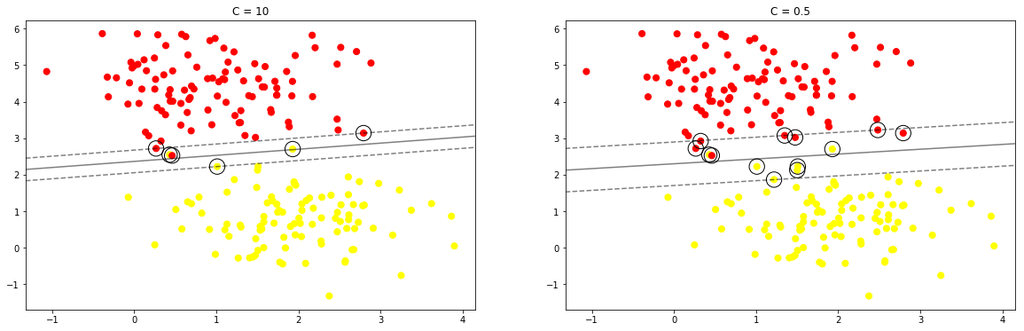

```python
# 한 화면에 그래프 창이 두개가 뜨도록 만들어 보자.
# plt의 figure라는 클래스를 사용하여 figsize를 (20,6)으로 갖는 fig라는 객체를 생성해둠.
# fig에서 add_subplot이라는 함수를 사용하여 ax1과 ax2라는 두개의 그래프창을 생성함.
# ax1은 (1,2)의 크기를 갖고 1번 자리에 표시, ax2는 (1,2)의 크기를 갖고 2번 자리에 표시
fig= plt.figure(figsize=(20,6))
ax1=fig.add_subplot(1,2,1)
ax2=fig.add_subplot(1,2,2)

# 두개의 그래프 창에 각각 C=10일때와, 0.5 때의 그림을 그려본다.
# X의 첫번째 변수와 두번째 변수를 사용하는 scatter plot을 그림, c=color, s=점의 크기, cmap=colormap
# C=10일때의 model1을 사용, ax=ax1사용, 결정경계를 그린다.
# 그래프의 제목을 'C = 10'이라 한다.
ax1.scatter(x[:, 0], x[:, 1], c=y, s=50, cmap='autumn')
util.plot_decision(model1,ax=ax1)
ax1.set_title('C = 10')

# X의 첫번째 변수와 두번째 변수를 사용하는 scatter plot을 그림, c=color, s=점의 크기, cmap=colormap
# C=0.5일때의 model1을 사용, ax=ax1사용, 결정경계를 그린다.
# 그래프의 제목을 'C = 0.5'라 한다.
ax2.scatter(x[:, 0], x[:, 1], c=y, s=50, cmap='autumn')
util.plot_decision(model2,ax=ax2)
ax2.set_title('C = 0.5')
```

C값이 클수록 더 엄격하게 분할 띠를 형성하며, C값이 작을때는 오류를 어느정도 허용하면서 분할 띠를 형성한다.

## Beyond linear boundaries: Kernel SVM

어떤 데이터는 주어진 차원공간 안에서 단순하게 분리가 어려운 경우가 있다.  
다음으로 소개할 커널 SVM은 그러한 경우에 사용될 수 있는 효과적인 모델이다.

```python
# sklearn 라이브러리의 samples_generator에서 두 부류의 원모양 데이터를 제공하는 make_circles 함수를 불러오자.
from sklearn.datasets.samples_generator import make_circles
```

```python
# 샘플개수 500개, factor(바깥쪽 원과 안쪽 원 사이의 Scale) =.1로 지정, noise(데이터의 표준편차)=.1로 지정하여 데이터 생성.
x, y = make_circles(500, factor=.1, noise=.1)
```

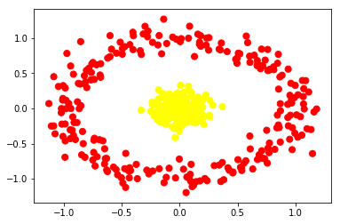

```python
# 생성된 데이터를 그래프에 표현.
# (x의 첫번째 열과 두번째 열을 사용, c는 점의 색깔, s는 점의 크기, cmap은 colormap)
plt.scatter(x[:, 0], x[:, 1], c=y, s=50, cmap='autumn')
```

위와 같은 모습을 띄는 데이터를 단순 선형분리 svm을 사용하여 결정경계를 그려보자.

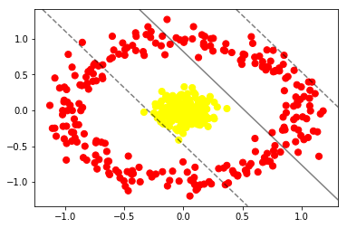

```python
# 생성된 데이터를 그래프에 표현.
# (x의 첫번째 열과 두번째 열을 사용, c는 점의 색깔, s는 점의 크기, cmap은 colormap)
plt.scatter(x[:, 0], x[:, 1], c=y, s=50, cmap='autumn')

# 'linear' 커널을 옵션으로 지정한 SVC의 인스턴스 model_circle 생성
model_circle = SVC(kernel='linear')

# 앞서 생성한 x, y를 model_circle에 피팅
model_circle.fit(x, y)

# 생성한 모델의 결정경계선 그리기
util.plot_decision(model_circle,plot_support=False)
```

위와 같은 모습을 띄는 두 부류의 데이터는 기존의 선형분리선으로는 분류하기 어렵다.  
만약 이 데이터를 더 높은 차원으로 투영 할 수 있다면 어떨까?

우리가 생성한 x데이터를 사용하여 차원을 확장하고, 시각화를 진행해보자.

```python
# x[:,0]에 해당하는 x1과 X[:,1]에 해당하는 x2를 사용하여 새로운 차원의 r을 생성
r=np.exp(-(x**2).sum(1))
```

기존 2차원에 존재하던 데이터를 3차원 상에 투영시켜 시각화 해보도록 하자.

```python
# 3차원 그래프를 사용하기 위해 mpl_toolkits.mplot3d에서 Axes3D라는 모듈을 불러온다.
from mpl_toolkits.mplot3d import Axes3D
```

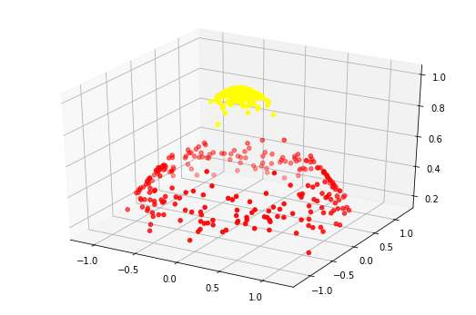

```python
# plt의 figure 클래스를 사용해서 크기가 (9,6)인 fig라는 객체를 생성해 놓는다.
fig=plt.figure(figsize=(9,6))
# fig에서 add_subplot이라는 함수를 사용하여 3차원 공간을 쓰는 ax을 생성해 놓는다.
ax=fig.add_subplot(1,1,1,projection='3d')
# xs에는 x[:,0]의 값을 ys에는 x[:,1]의 값을, zs에는 r값을 넣는 3차원 scatter plot을 생성한다.
# c=color, cmap=colormap
ax.scatter(xs=x[:,0],ys=x[:,1],zs=r,c=y,cmap='autumn')
```

추가적인 차원을 사용함에 따라 이 데이터는 'r=0.7'부근을 기점으로 분리될수 있다.  
다만, 항상 위의 예제처럼 손쉽게 변환 함수를 직접 구할수 있는 것이 아니기 때문에, 라이브러리를 사용하여보자.  
sklearn 라이브러리에서는 적절한 옵션을 지정하여 커널 svm을 구현해 볼 수 있다.

```python
# kernel='rbf'로 지정하고 gamma='auto', C=1E10으로 하는 model_kernel이라는 객체를 생성하자.
model_kernel = SVC(kernel='rbf', gamma='auto',C=1E10)
```

```python
# model_kernel의 fit함수를 사용하여 (x,y)데이터에 대한 커널 SVM모델을 생성하자.
model_kernel.fit(x, y)
```

```
SVC(C=10000000000.0, cache_size=200, class_weight=None, coef0=0.0,
  decision_function_shape='ovr', degree=3, gamma='auto', kernel='rbf',
  max_iter=-1, probability=False, random_state=None, shrinking=True,
  tol=0.001, verbose=False)
```

기존의 scattter plot을 그리고, model_kernel을 사용한 결정경계가 추가로 그려지도록 해보자.

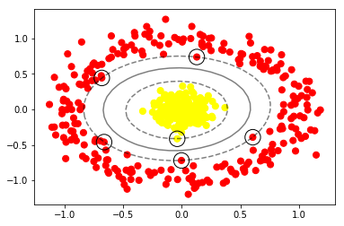

```python
# 기존의 scatter plot을 그리자.
# (X의 첫번째 열과 두번째 열을 사용, c는 점의 색깔, s는 점의 크기, cmap은 colormap)
plt.scatter(x[:, 0], x[:, 1], c=y, s=50, cmap='autumn')

# model_kernel을 결정경계를 그려주는 함수인 plot_decision에 넣는다.
util.plot_decision(model_kernel)
```

위와 같이 커널 서포트 벡터 머신을 사용하여 적절한 비선형 결정경계를 학습할 수 있으며,  
SVC()의 parameter인 'gamma'를 조절하여, 결정경계를 타이트하게 학습할 것인지, 여유있게 학습할 것인지 정할 수 있다.

### 가우시안 RBF커널의 gamma 값을 작게 지정했을 때 : gamma = 1

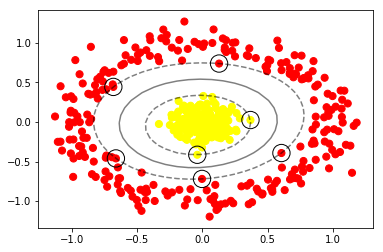

```python
# kernel='rbf'로 지정하고 gamma=1, C=1E10으로 하는 model_kernel이라는 객체를 생성하자.
model_kernel = SVC(kernel='rbf', gamma=1,C=1E10)

# model_kernel의 fit함수를 사용하여 (x,y)데이터에 대한 커널 SVM모델을 생성하자.
model_kernel.fit(x, y)

# 기존의 scatter plot을 그리자.
# (x의 첫번째 열과 두번째 열을 사용, c는 점의 색깔, s는 점의 크기, cmap은 colormap)
plt.scatter(x[:, 0], x[:, 1], c=y, s=50, cmap='autumn')

# model_kernel을 결정경계를 그려주는 함수인 plot_decision에 넣는다.
util.plot_decision(model_kernel)
```

### 가우시안 RBF커널의 gamma 값을 크게 지정했을 때 : gamma = 10

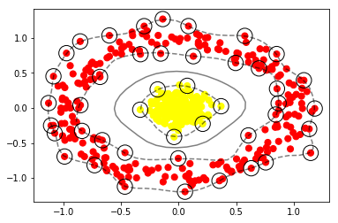

```python
# kernel='rbf'로 지정하고 gamma=10, C=1E10으로 하는 model_kernel이라는 객체를 생성하자.
model_kernel = SVC(kernel='rbf', gamma=10, C=1E10)

# model_kernel의 fit함수를 사용하여 (x,y)데이터에 대한 커널 SVM모델을 생성하자.
model_kernel.fit(x, y)

# 기존의 scatter plot을 그리자.
# (X의 첫번째 열과 두번째 열을 사용, c는 점의 색깔, s는 점의 크기, cmap은 colormap)
plt.scatter(x[:, 0], x[:, 1], c=y, s=50, cmap='autumn')

# model_kernel을 결정경계를 그려주는 함수인 plot_decision에 넣는다.
util.plot_decision(model_kernel)
```